# Caret / Recursive Partitioning

Thuyen Nguyen

May 15, 2017

## Exercise 1: caret/logistic regression (5 points)

Rebuild your logistic regression model from the previous week, this time using the `caret` package.

- Calculate the training or apparent performance of the model.
- Calculate an unbiased measure of performance
- Create a ROC Curve for your model

Show all work.

```r
# Your Work Here

#loaddata

airports <- read_csv("~/Documents/CSX460/02-building-blocks/02-exercise-nycflights/data/airports.csv") %>% setDT
flights <- read_csv("~/Documents/CSX460/02-building-blocks/02-exercise-nycflights/data/flights.csv") %>% setDT
planes <- read_csv("~/Documents/CSX460/02-building-blocks/02-exercise-nycflights/data/planes.csv") %>% setDT
weather <- read_csv("~/Documents/CSX460/02-building-blocks/02-exercise-nycflights/data/weather.csv") %>% setDT
data_join <- flights %>%
  transform(dephour = floor(dep_time / 100)) %>%
  left_join(.,planes, by=c("tailnum" = "tailnum")) %>%
  left_join(.,airports,by=c("origin"="faa"))  %>%
  left_join(.,airports,by=c("dest"="faa")) %>%
  left_join(.,weather, by=c("origin"="origin","dephour"="hour","year.x"="year","month"="month","day"="day"))
head(data_join)
```

```
##   year.x month day dep_time sched_dep_time dep_delay arr_time
## 1   2013     1   1      517            515         2      830
## 2   2013     1   1      533            529         4      850
## 3   2013     1   1      542            540         2      923
## 4   2013     1   1      544            545        -1     1004
## 5   2013     1   1      554            600        -6      812
## 6   2013     1   1      554            558        -4      740
##   sched_arr_time arr_delay carrier flight tailnum origin dest air_time
## 1            819        11      UA   1545  N14228    EWR  IAH      227
## 2            830        20      UA   1714  N24211    LGA  IAH      227
## 3            850        33      AA   1141  N619AA    JFK  MIA      160
## 4           1022       -18      B6    725  N804JB    JFK  BQN      183
## 5            837       -25      DL    461  N668DN    LGA  ATL      116
## 6            728        12      UA   1696  N39463    EWR  ORD      150
##   distance hour minute         time_hour.x dephour year.y
```

[output cut: 41 more lines]

```r
#isolate just the lateflight
data_join$lateflight <- factor(data_join$arr_delay >= 20)
#data_join$lateflight %>% qplot

#remove NA data
data_join <- na.omit(data_join [,c("lateflight","dep_delay","month","air_time","distance","carrier","lat.y","lon.y","arr_delay")])

#create training data
set.seed(1234)
inTraining <- createDataPartition(data_join$lateflight, p=0.75,list=FALSE)

#Train the model using caret

train <- trainControl(method = "cv", number = 20)
training <- data_join[inTraining,]
testing <- data_join[-inTraining,]

fitformula <- lateflight ~ dep_delay + month + air_time + distance + carrier + lat.y + lon.y
fitmodel <- train(fitformula, data = training, trControl = train, method = "glm")
```

[output not shown]

```r
 predictions <- predict(fitmodel, testing)
 confusionMatrix(predictions,testing$lateflight)
```

```
## Confusion Matrix and Statistics
##
##           Reference
## Prediction FALSE  TRUE
##      FALSE 61746  4268
##      TRUE   1358 12580
##
##                Accuracy : 0.9296
##                  95% CI : (0.9278, 0.9314)
##     No Information Rate : 0.7893
##     P-Value [Acc > NIR] : < 2.2e-16
##
##                   Kappa : 0.7742
##  Mcnemar's Test P-Value : < 2.2e-16
##
##             Sensitivity : 0.9785
##             Specificity : 0.7467
##          Pos Pred Value : 0.9353
##          Neg Pred Value : 0.9026
##              Prevalence : 0.7893
##          Detection Rate : 0.7723
##    Detection Prevalence : 0.8257
##       Balanced Accuracy : 0.8626
##
##        'Positive' Class : FALSE
##
```

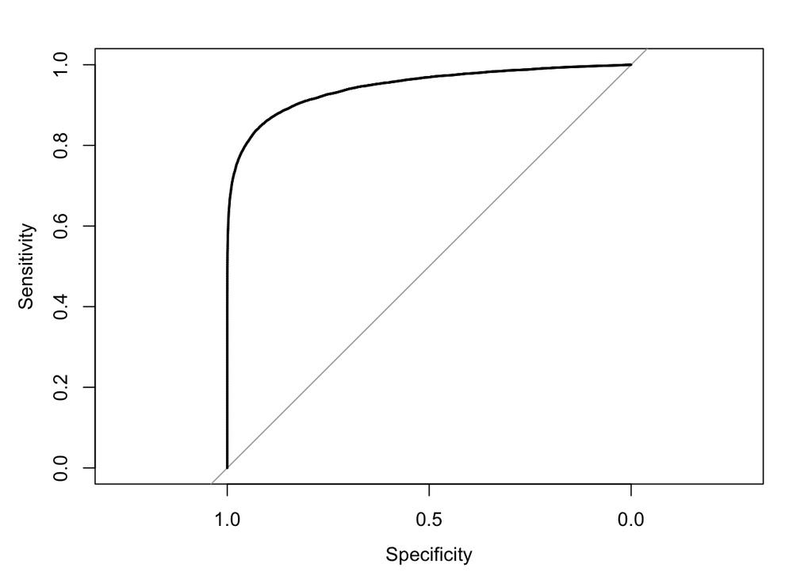

```r
 fitLinear <- arr_delay ~ dep_delay + month + air_time + distance + carrier + lat.y + lon.y
 LinearModel <- train(fitLinear, data = training, trControl = train, method = "glm")
 predictLinear <- predict(LinearModel, testing)
 plot(roc(testing$lateflight,predictLinear))
```

## Exercise 2: caret/rpart (5 points)

Using the `caret` and `rpart` packages, create a **classification** model for flight delays using your NYC FLight data. Your solution should include:

- The use of `caret` and `rpart` to train a model.
- An articulation of the the problem your are
- An naive model
- An unbiased calculation of the performance metric
- A plot of your model – (the actual tree; there are several ways to do this)
- A discussion of your model

Show and describe all work

```r
# Your Work Here

#Naive Model, randome number

set.seed(1234)
y <- sample(c(TRUE,FALSE),length(training$lateflight), TRUE)
confusionMatrix(y, training$lateflight)
```

```
## Confusion Matrix and Statistics
##
##           Reference
## Prediction FALSE  TRUE
##      FALSE 94571 25401
##      TRUE  94741 25144
##
##                Accuracy : 0.4991
##                  95% CI : (0.4971, 0.5011)
##     No Information Rate : 0.7893
##     P-Value [Acc > NIR] : 1
##
##                   Kappa : -0.002
##  Mcnemar's Test P-Value : <2e-16
##
##             Sensitivity : 0.4996
##             Specificity : 0.4975
##          Pos Pred Value : 0.7883
##          Neg Pred Value : 0.2097
##              Prevalence : 0.7893
##          Detection Rate : 0.3943
##    Detection Prevalence : 0.5002
##       Balanced Accuracy : 0.4985
##
##        'Positive' Class : FALSE
##
```

```r
#unbiased calculation

formula <- lateflight ~ dep_delay + month + air_time + distance + carrier + lat.y + lon.y
model <- train(formula, data = training, trControl = train, method = "rpart")
 unBiased <- predict(model, testing)
 confusionMatrix(unBiased,testing$lateflight)
```

```
## Confusion Matrix and Statistics
##
##           Reference
## Prediction FALSE  TRUE
##      FALSE 61831  5368
##      TRUE   1273 11480
##
##                Accuracy : 0.9169
##                  95% CI : (0.915, 0.9188)
##     No Information Rate : 0.7893
##     P-Value [Acc > NIR] : < 2.2e-16
##
##                   Kappa : 0.7259
##  Mcnemar's Test P-Value : < 2.2e-16
##
##             Sensitivity : 0.9798
##             Specificity : 0.6814
##          Pos Pred Value : 0.9201
##          Neg Pred Value : 0.9002
##              Prevalence : 0.7893
##          Detection Rate : 0.7734
##    Detection Prevalence : 0.8405
##       Balanced Accuracy : 0.8306
##
##        'Positive' Class : FALSE
##
```

```r
#training the model

TuneModel <- rpart(lateflight ~ dep_delay + month + air_time + distance + carrier + lat.y + lon.y,
                   data = training,
                   method = "class",
                   control = list(cp = 0.01, minsplit = 5, maxdepth = 20))
TrainPrediction <- predict(TuneModel, testing,type='class')
confusionMatrix(TrainPrediction, testing$lateflight)
```

```
## Confusion Matrix and Statistics
##
##           Reference
## Prediction FALSE  TRUE
##      FALSE 61587  5219
##      TRUE   1517 11629
##
##                Accuracy : 0.9157
##                  95% CI : (0.9138, 0.9177)
##     No Information Rate : 0.7893
##     P-Value [Acc > NIR] : < 2.2e-16
##
##                   Kappa : 0.7245
##  Mcnemar's Test P-Value : < 2.2e-16
##
##             Sensitivity : 0.9760
##             Specificity : 0.6902
##          Pos Pred Value : 0.9219
##          Neg Pred Value : 0.8846
##              Prevalence : 0.7893
##          Detection Rate : 0.7703
##    Detection Prevalence : 0.8356
##       Balanced Accuracy : 0.8331
##
##        'Positive' Class : FALSE
##
```

```r
printcp(TuneModel)
```

```
##
## Classification tree:
## rpart(formula = lateflight ~ dep_delay + month + air_time + distance +
##     carrier + lat.y + lon.y, data = training, method = "class",
##     control = list(cp = 0.01, minsplit = 5, maxdepth = 20))
##
## Variables actually used in tree construction:
## [1] dep_delay
##
## Root node error: 50545/239857 = 0.21073
##
## n= 239857
##
##        CP nsplit rel error  xerror      xstd
## 1 0.59986      0   1.00000 1.00000 0.0039516
## 2 0.01000      1   0.40014 0.40014 0.0026924
```

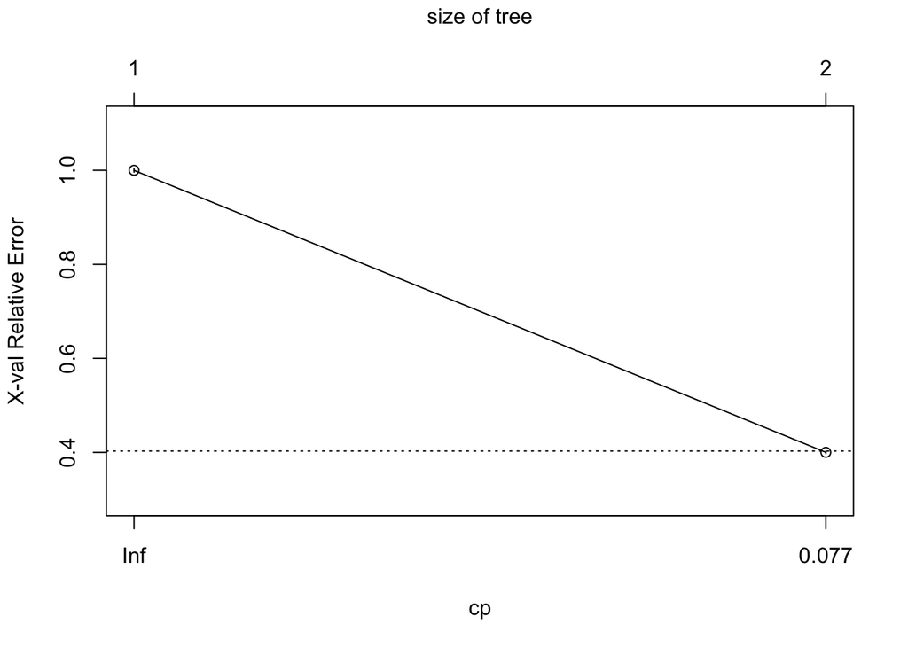

```r
plotcp(TuneModel)
```

```r
summary(TuneModel)
```

```
## Call:
## rpart(formula = lateflight ~ dep_delay + month + air_time + distance +
##     carrier + lat.y + lon.y, data = training, method = "class",
##     control = list(cp = 0.01, minsplit = 5, maxdepth = 20))
##   n= 239857
##
##          CP nsplit rel error    xerror        xstd
## 1 0.5998615      0 1.0000000 1.0000000 0.003951607
## 2 0.0100000      1 0.4001385 0.4001385 0.002692388
##
## Variable importance
## dep_delay
##       100
##
## Node number 1: 239857 observations,    complexity param=0.5998615
##   predicted class=FALSE  expected loss=0.2107297  P(node) =1
##     class counts: 189312 50545
##    probabilities: 0.789 0.211
##   left son=2 (200127 obs) right son=3 (39730 obs)
##   Primary splits:
##       dep_delay < 25.5  to the left,  improve=42858.88000, (0 missing)
##       carrier   splits as  RLLRLRRRLRRLLLRR, improve=  781.75560, (0 missing)
##       month     < 8.5   to the right, improve=  328.67280, (0 missing)
##       air_time  < 364.5 to the left,  improve=  186.76360, (0 missing)
##       distance  < 880   to the right, improve=   80.34311, (0 missing)
##
## Node number 2: 200127 observations
##   predicted class=FALSE  expected loss=0.07755076  P(node) =0.8343596
##     class counts: 184607 15520
##    probabilities: 0.922 0.078
##
## Node number 3: 39730 observations
##   predicted class=TRUE   expected loss=0.1184244  P(node) =0.1656404
##     class counts:  4705 35025
##    probabilities: 0.118 0.882
```

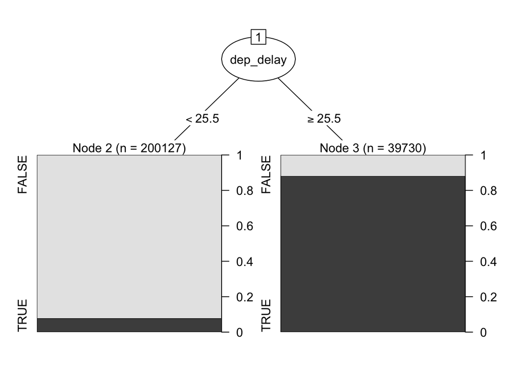

```r
#plot the model

rpartTree <- as.party(TuneModel)
plot(rpartTree)
```

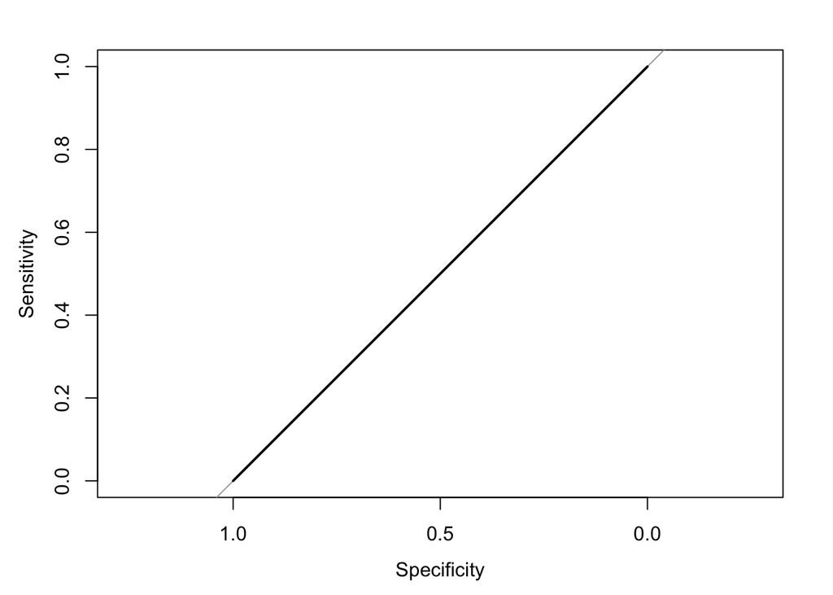

```r
#Producing an ROC by switching to linear model

TuneModel <- rpart(arr_delay ~ dep_delay + month + air_time + distance + carrier + lat.y + lon.y,
                   data = data_join,
                   method = "class",
                   control = list(cp = 0.01, minsplit = 5, maxdepth = 20))
TrainPrediction <- predict(TuneModel, testing,type="class")
plot(roc(testing$lateflight,as.numeric(TrainPrediction)))
```

### Questions:

- Discuss the difference between the models and why you would use one model over the other?

The CART - regression tree model performs not as well as the straight linear model. The linear model has a good kappa and an accuracy rate of 92%. The data set we have does not have discontuos y values. And therefore the regression tree method wont be as good.

- How might you produce an ROC type curve for the *rpart* model?

We need to compare the the linear model prediction. See above.